# IML_Week_4_Assignment_Learner_template

#### C) Split the data into a training set and a test set (70%, 30%). Use `random.seed(4)` to make the training data reproducible.

Link to linear model: https://scikit-learn.org/stable/modules/generated/sklearn.model_selection.train_test_split.html

```python
# BEGIN SOLUTION
classes = [f"mpg <= {median_mpg}(median)", f"mpg > {median_mpg}(median)"]
X = df.drop(['mpg', 'mpg01', 'name'], axis=1)
Y = df['mpg01']
X_train, X_test, y_train, y_test = train_test_split(X, Y, test_size=0.3, random_state=4)
sc = StandardScaler()
x_train = sc.fit_transform(X_train)
x_train = pd.DataFrame(x_train, columns = X_train.columns)
x_test = sc.transform(X_test)
x_test = pd.DataFrame(x_test, columns=X_test.columns)
## The scaling is done independently for test and train to make sure we care not leaking information between test and training set.
# END SOLUTION
```

#### d) Perform LDA on the training data in order to predict `mpg01` using the variables that seemed most associated with `mpg01` in (b). What is the test error of the model obtained?

```python
# BEGIN SOLUTION
lda = LinearDiscriminantAnalysis()
lda.fit(x_train, y_train)
print("The intercept is ", lda.intercept_)
print("The coefficients are ", lda.coef_)

# END SOLUTION
```

```
The intercept is  [0.2420964]
The coefficients are  [[-1.91466613  0.47924736  1.40132193 -3.68829299  0.20536247  1.15660948
   0.09979711]]
```

```
Confusion Matrix:
```

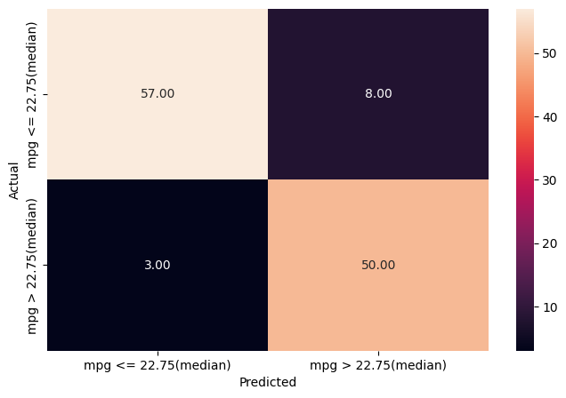

```
array([[57,  8],
       [ 3, 50]])
```

```python
# BEGIN SOLUTION
y_predictions = lda.predict(x_test)
metrics_score(y_test, y_predictions, classes)
# END SOLUTION
```

For LDA the test error is 11 out of 118 obsevations. ie. we have $\frac{11}{118}$ as test Error Rate

```python
# BEGIN SOLUTION
print(classification_report(y_test, y_predictions))
# END SOLUTION
```

```
              precision    recall  f1-score   support

           0       0.95      0.88      0.91        65
           1       0.86      0.94      0.90        53

    accuracy                           0.91       118
   macro avg       0.91      0.91      0.91       118
weighted avg       0.91      0.91      0.91       118
```

**Linear Discriminant Analysis (LDA):**

- Accuracy: 91%
- Precision: 0.95 (mpg01=0), 0.86 (mpg01=1)
- Recall: 0.88 (mpg01=0), 0.94 (mpg01=1)
- F1-score: 0.91 (mpg01=0), 0.90 (mpg01=1)

LDA performs petty well indicating that assumption of equal covariance matrices holds true.

#### e) Perform QDA on the training data in order to predict `mpg01` using the variables that seemed most associated with `mpg01` in (b). What is the test error of the model obtained?

```python
# BEGIN SOLUTION
qda = QuadraticDiscriminantAnalysis()
qda.fit(x_train, y_train)
# END SOLUTION
```

```
QuadraticDiscriminantAnalysis()
```

```
Confusion Matrix:
```

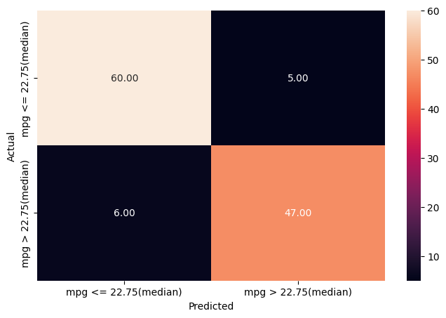

```
array([[60,  5],
       [ 6, 47]])
```

```python
 # BEGIN SOLUTION
y_predictions = qda.predict(x_test)
metrics_score(y_test, y_predictions, classes)


# END SOLUTION
```

For QDA the test error is 11 out of 118 obsevations. ie. we have $\frac{11}{118}$ as test Error Rate

```python
# BEGIN SOLUTION
print(classification_report(y_test, y_predictions))
# END SOLUTION
```

```
              precision    recall  f1-score   support

           0       0.91      0.92      0.92        65
           1       0.90      0.89      0.90        53

    accuracy                           0.91       118
   macro avg       0.91      0.90      0.91       118
weighted avg       0.91      0.91      0.91       118
```

**Quadratic Discriminant Analysis (QDA):**

- Accuracy: 91%
- Precision: 0.91 (mgp01=0), 0.90 (mgp01=1)
- Recall: 0.92 (mgp01=0), 0.89 (mgp01=1)
- F1-score: 0.92 (mgp01=0), 0.90 (mgp01=1)

#### f) Perform logistic regression on the training data in order to predict `mpg01` using the variables that seemed most associated with `mpg01` in (b). What is the test error of the model obtained?

Link to linear model: https://scikit-learn.org/stable/modules/generated/sklearn.linear_model.LogisticRegression.html

```python
# BEGIN SOLUTION
lg = LogisticRegression()

lg.fit(x_train, y_train)
print("The intercept is ", lg.intercept_)
print("The coefficients are ", lg.coef_)
# END SOLUTION
```

```
The intercept is  [-0.64221592]
The coefficients are  [[-0.51668841 -0.53935564 -1.00764327 -2.18514542 -0.06723588  1.10675166
   0.02973243]]
```

```
Confusion Matrix:
```

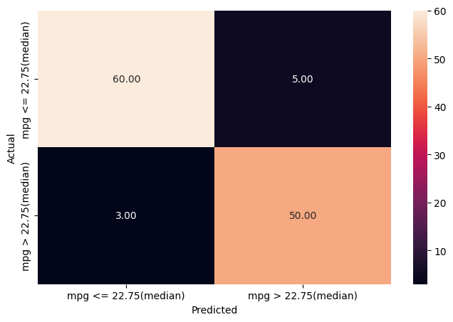

```
array([[60,  5],
       [ 3, 50]])
```

```python
# BEGIN SOLUTION
y_predictions = lg.predict(x_test)
metrics_score(y_test, y_predictions, classes)

# END SOLUTION
```

```python
# BEGIN SOLUTION
print(classification_report(y_test, y_predictions))
# END SOLUTION
```

```
              precision    recall  f1-score   support

           0       0.95      0.92      0.94        65
           1       0.91      0.94      0.93        53

    accuracy                           0.93       118
   macro avg       0.93      0.93      0.93       118
weighted avg       0.93      0.93      0.93       118
```

For Logistic Regression the test error is 8 out of 118 obsevations. ie. we have $\frac{8}{118}$ as test Error Rate

**Logistic Regression:**

- Accuracy: 93%
- Precision: 0.95 (mpg01=0), 0.91 (mpg01=1)
- Recall: 0.92 (mpg01=0), 0.94 (mpg01=1)
- F1-score: 0.94 (mpg01=0), 0.93 (mpg01=1)

Logistic Regression has the highest accuracy and F1-scores for both classes, indicating a slightly better overall performance compared to LDA and QDA.

**Conclusion**